# Explore Data using R

Write your name

This document is a live code demo.. please edit it as you see fit. Add your own text between the code chunks as discussed yesterday..

Let us begin!

# Step One: Load Packages

```r
# Loading the Packages
library(tidyverse)
library(here)
```

# Step Two: Import Data

### About the data

The Annual Health Survey (AHS) was conceived in 2005 under the Chairmanship of the then Prime Minister. It was decided that “there should be an Annual Health Survey of all districts which could be published/ monitored and compared against benchmarks”.

This dataset is a subset of the annual health survey data and contains information on the deaths in the district of Dhanbad, Jharkhand. It contains information on the age, gender, date of death and other socio demographic attributes including income, religion, literacy, occupation, indicators for standard of living index (SLI) etc. More information on the data can be found at: https://censusindia.gov.in/vital_statistics/AHSBulletins/ahs.html.

> The dataset we will be working with has been cleaned (to an extent) for the purposes of this workshop. The raw dataset and many more such data are publicly available at: https://data.gov.in/ for research purposes.

```r
# This is going to be your file path using here

# file_path <- here::here("data", "csv_data.csv")
#
# # Loads Data
#
# df <- readr::read_csv(file_path)


df <- read_csv(here("data", "csv_data.csv"))
```

# Step Three: Clean Variable Names

```r
# Check the names of the first five columns

df %>% names() %>% head()
```

```
## [1] "Id"          "M Id"        "Client M Id" "Hl Id"       "State"
## [6] "District"
```

```r
# Lets try to clean them

df %>% janitor::clean_names() %>% names() %>% head()
```

```
## [1] "id"          "m_id"        "client_m_id" "hl_id"       "state"
## [6] "district"
```

```r
# Save the dataframe after cleaning names

df <- df %>% janitor::clean_names()
```

# Step Four: View Data

```r
# View(df)
```

# Step Five: Select Variables of Interest

```r
df <- df %>% dplyr::select(state, # state
                     district, # district
                     rural, # rural/urban
                     deceased_sex, # gender
                     date_of_death,
                     month_of_death,
                     year_of_death,
                     age_of_death_below_one_month, # age in days
                     age_of_death_below_eleven_month, # age in months
                     age_of_death_above_one_year, # age in years
                     treatment_source,
                     place_of_death,
                     is_death_reg, # Yes No
                     is_death_certificate_received, # Yes No 0(unknown)
                     death_symptoms,
                     death_period,
                     months_of_pregnancy, # for maternal deaths
                     factors_contributing_death,
                     factors_contributing_death_2,
                     symptoms_of_death,
                     tim_bet_onset_complctn_n_death,
                     religion,
                     social_group_code,
                     house_structure,
                     diagnosed_for,
                     diagnosis_source,
                     regular_treatment,
                     house_structure,
                     owner_status,
                     drinking_water_source,
                     toilet_used)
```

# Step Six: Expolore Data

```r
df %>% dim()
```

```
## [1] 3055   30
```

```r
df %>% nrow()
```

```
## [1] 3055
```

```r
df %>% ncol()
```

```
## [1] 30
```

```r
df %>% glimpse()
```

```
## Rows: 3,055
## Columns: 30
## $ state                           <chr> "JHARKHAND", "JHARKHAND", "JHARKHAND",…
## $ district                        <chr> "DHANBAD", "DHANBAD", "DHANBAD", "DHAN…
## $ rural                           <chr> "Rural", "Rural", "Rural", "Rural", "R…
## $ deceased_sex                    <chr> "Male", "Male", "Male", "Female", "Mal…
## $ date_of_death                   <dbl> 0, 0, 0, 14, 11, 2, 30, 0, 0, 0, 0, 0,…
## $ month_of_death                  <dbl> 10, 8, 2, 5, 10, 8, 9, 6, 1, 3, 5, 6, …
## $ year_of_death                   <dbl> 2007, 2008, 2007, 2008, 2007, 2008, 20…
## $ age_of_death_below_one_month    <dbl> NA, NA, NA, NA, NA, NA, NA, NA, NA, NA…
## $ age_of_death_below_eleven_month <dbl> NA, NA, NA, NA, NA, NA, NA, NA, NA, 1,…
## $ age_of_death_above_one_year     <dbl> 50, 35, 2, 60, 27, 35, 21, 1, 70, NA, …
## $ treatment_source                <chr> "No Medical attention", "No Medical at…
## $ place_of_death                  <chr> "At home", "At home", "At home", "At h…
## $ is_death_reg                    <chr> "No", "No", "No", "Yes", "No", "Yes", …
```

[output cut: 17 more lines]

```r
df %>% skimr::skim()
```

Data summary

| Name | Piped data |
| --- | --- |
| Number of rows | 3055 |
| Number of columns | 30 |
| _______________________ |  |
| Column type frequency: |  |
| character | 23 |
| numeric | 7 |
| ________________________ |  |
| Group variables | None |

**Variable type: character**

| skim_variable | n_missing | complete_rate | min | max | empty | n_unique | whitespace |
| --- | --- | --- | --- | --- | --- | --- | --- |
| state | 0 | 1.00 | 9 | 9 | 0 | 1 | 0 |
| district | 0 | 1.00 | 7 | 7 | 0 | 1 | 0 |
| rural | 0 | 1.00 | 5 | 5 | 0 | 2 | 0 |
| deceased_sex | 0 | 1.00 | 4 | 6 | 0 | 2 | 0 |
| treatment_source | 1 | 1.00 | 6 | 32 | 0 | 14 | 0 |
| place_of_death | 0 | 1.00 | 7 | 18 | 0 | 4 | 0 |
| is_death_reg | 0 | 1.00 | 2 | 10 | 0 | 3 | 0 |
| is_death_certificate_received | 740 | 0.76 | 1 | 3 | 0 | 3 | 0 |
| death_symptoms | 2634 | 0.14 | 6 | 49 | 0 | 15 | 0 |
| death_period | 3029 | 0.01 | 15 | 26 | 0 | 4 | 0 |
| factors_contributing_death | 3027 | 0.01 | 6 | 77 | 0 | 6 | 0 |
| factors_contributing_death_2 | 3029 | 0.01 | 6 | 35 | 0 | 7 | 0 |
| symptoms_of_death | 3026 | 0.01 | 6 | 41 | 0 | 8 | 0 |
| tim_bet_onset_complctn_n_death | 3025 | 0.01 | 9 | 18 | 0 | 6 | 0 |
| religion | 36 | 0.99 | 4 | 9 | 0 | 6 | 0 |
| social_group_code | 36 | 0.99 | 2 | 6 | 0 | 3 | 0 |
| house_structure | 154 | 0.95 | 5 | 10 | 0 | 4 | 0 |
| diagnosed_for | 43 | 0.99 | 7 | 45 | 0 | 30 | 0 |
| diagnosis_source | 2426 | 0.21 | 6 | 34 | 0 | 14 | 0 |
| regular_treatment | 2426 | 0.21 | 2 | 17 | 0 | 3 | 0 |
| owner_status | 154 | 0.95 | 5 | 6 | 0 | 3 | 0 |
| drinking_water_source | 154 | 0.95 | 9 | 47 | 0 | 9 | 0 |
| toilet_used | 154 | 0.95 | 14 | 68 | 0 | 9 | 0 |

**Variable type: numeric**

| skim_variable | n_missing | complete_rate | mean | sd | p0 | p25 | p50 | p75 | p100 | hist |
| --- | --- | --- | --- | --- | --- | --- | --- | --- | --- | --- |
| date_of_death | 0 | 1.00 | 7.14 | 9.64 | 0 | 0 | 0 | 14 | 31 | ▇▁▁▁▁ |
| month_of_death | 0 | 1.00 | 6.56 | 3.64 | 0 | 3 | 7 | 10 | 12 | ▆▃▇▆▇ |
| year_of_death | 0 | 1.00 | 2009.00 | 1.43 | 2007 | 2008 | 2009 | 2010 | 2011 | ▇▇▇▇▇ |
| age_of_death_below_one_month | 2741 | 0.10 | 3.33 | 5.46 | 0 | 0 | 1 | 4 | 28 | ▇▁▁▁▁ |
| age_of_death_below_eleven_month | 2962 | 0.03 | 3.51 | 2.83 | 1 | 1 | 3 | 4 | 11 | ▇▂▂▁▁ |
| age_of_death_above_one_year | 408 | 0.87 | 52.69 | 23.46 | 1 | 38 | 58 | 70 | 99 | ▃▃▅▇▂ |
| months_of_pregnancy | 3028 | 0.01 | 6.15 | 3.45 | 1 | 3 | 9 | 9 | 9 | ▃▂▂▁▇ |

## Gender

### Distribution of Gender among deceased

```r
df %>% pull(deceased_sex) %>% table()
```

```
## .
## Female   Male
##   1356   1699
```

### Visualize distribution of gender

```r
# df %>% pull(deceased_sex) %>% plot()
# df %>% pull(deceased_sex) %>% class()
df %>% pull(deceased_sex) %>% as.factor() %>% class()
```

```
## [1] "factor"
```

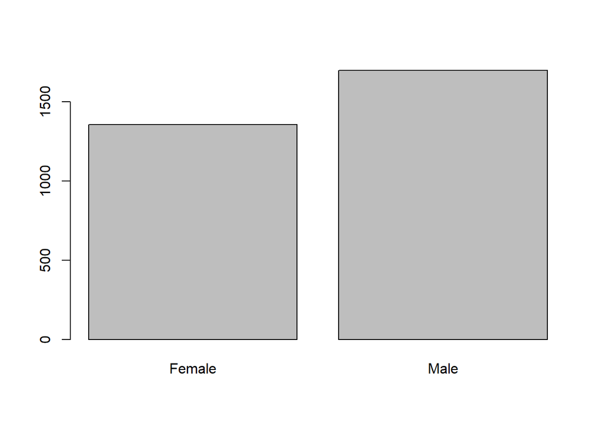

```r
df %>% pull(deceased_sex) %>% as.factor() %>% plot()
```

## Age

```r
# age_of_death_below_one_month, # age in days
# age_of_death_below_eleven_month, # age in months
# age_of_death_above_one_year, # age in years

df %>% pull(age_of_death_above_one_year) %>% summary()
```

```
##    Min. 1st Qu.  Median    Mean 3rd Qu.    Max.    NA's
##    1.00   38.00   58.00   52.69   70.00   99.00     408
```

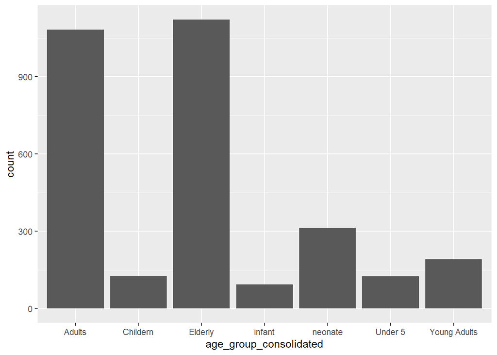

```r
# This is to create a column for neonate
df <- df %>%
  mutate(neonate = ifelse(is.na(age_of_death_below_one_month), "others", "neonate"))

# This is to create a column for infant
df <- df %>%
  mutate(infant = ifelse(is.na(age_of_death_below_eleven_month), "others", "infant"))


df <- df %>%
  mutate(age_group = ifelse(age_of_death_above_one_year <= 5, "Under 5",ifelse(age_of_death_above_one_year <= 14, "Childern", ifelse(age_of_death_above_one_year <= 25, "Young Adults", ifelse(age_of_death_above_one_year <= 60, "Adults", "Elderly")))))

# df$neonate
# df$infant
# df$age_group

df <- df %>% mutate(age_group_consolidated = ifelse(is.na(age_group), neonate, age_group)) %>% mutate(age_group_consolidated = ifelse(age_group_consolidated == "others", "infant", age_group_consolidated))


df %>%
  ggplot() +
  geom_bar(aes(x = age_group_consolidated))
```

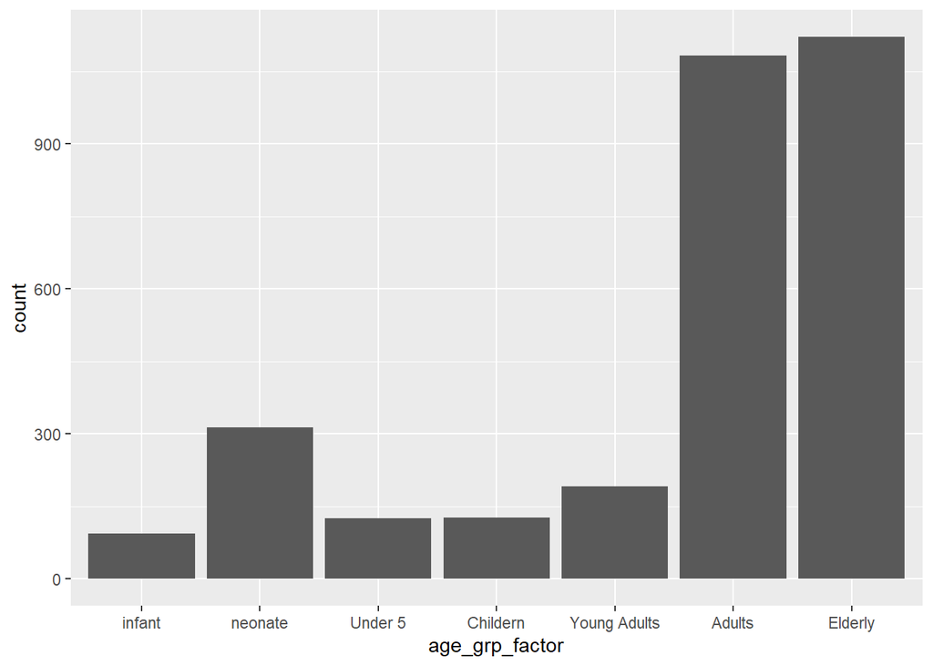

```r
df <- df %>%
  mutate(age_grp_factor = factor(age_group_consolidated, levels = c('infant','neonate',"Under 5", "Childern", "Young Adults", "Adults", "Elderly")))

df %>%
  ggplot() +
  geom_bar(aes(x = age_grp_factor))
```

```r
df %>% pull(age_of_death_above_one_year) %>% is.na() %>% summary()
```

```
##    Mode   FALSE    TRUE
## logical    2647     408
```

## Create Age in Years

```r
df %>% dplyr::select(age_of_death_below_eleven_month) %>% mutate(age_of_death_below_eleven_month/12)
```

```
## # A tibble: 3,055 × 2
##    age_of_death_below_eleven_month `age_of_death_below_eleven_month/12`
##                              <dbl>                                <dbl>
##  1                              NA                              NA
##  2                              NA                              NA
##  3                              NA                              NA
##  4                              NA                              NA
##  5                              NA                              NA
##  6                              NA                              NA
##  7                              NA                              NA
##  8                              NA                              NA
##  9                              NA                              NA
## 10                               1                               0.0833
## # … with 3,045 more rows
```

Now try for days in years

## Create Age Group

```r
# Using ifelse()
```

```r
# using case_when()
```

## Rename variables

```r
df <- df %>%
  rename(age = age_of_death_above_one_year) %>%
  rename(gender = deceased_sex)
```

## Create a categorical variable of Age Groups

```r
df <- df %>%
  mutate(age_new = ifelse(is.na(age), 1, age))
```

## Create a categorical variable of Age Groups